# JPMorgan Chase Institute Application Script

T. Morrison

November 17, 2016

For this script, I have put together an analysis of electricity prices in the United States. The data comes from the Energy Information Administration, and can be found in the “Supplemental Data” box here: http://www.eia.gov/electricity/sales_revenue_price/ as “1990-2015 Average Price by State by Provider”. The dataset consists of an average annual price for each state by sector (e.g. residential, commercial) and provider type (e.g. full-service provider, energy-only provider).

The analysis will focus on the effect of deregulating state electricity markets on energy prices.

This script contains all the necessary R code to download the data from the website, transform it into a format from which it can be analyzed, and an analysis of the data with various visualizations.

First, I will make use of a variety of supplemental R packages, loaded below:

```r
library(data.table)
library(dplyr)
library(ggplot2)
library(Cairo)
library(readxl)
library(tidyr)
library(scales)
library(ggthemes)
library(maps)
```

Then, download the data and load it into R environment:

```r
destfile <- tempfile(fileext = ".xlsx")
download.file("http://www.eia.gov/electricity/data/state/avgprice_annual.xlsx", destfile, mode="wb")
data <- read_excel(destfile, skip=1)
```

Then, manipulate the data to workable form with each column as a different variable:

```r
data <- gather(data, Sector, Price, -c(Year, State, `Industry Sector Category`))
setDT(data)
head(data)
```

```
##    Year State Industry Sector Category      Sector Price
## 1: 2015    AK  Total Electric Industry Residential 19.83
## 2: 2015    AL  Total Electric Industry Residential  11.7
## 3: 2015    AR  Total Electric Industry Residential  9.82
## 4: 2015    AZ  Total Electric Industry Residential 12.13
## 5: 2015    CA  Total Electric Industry Residential 16.99
## 6: 2015    CO  Total Electric Industry Residential 12.12
```

It is necessary to add a region column based on US Census Bureau regions- Northeast, Midwest, South, West, for later use, change some column types/names, and remove some outlier data:

```r
MW<-c("IL","OH","WI","ND","SD","NE","KS","IA","MN","IN","MO","MI")
W<-c("AZ","CO","ID","MT","NV","NM","UT","WY","AK","CA","HI","OR","WA")
S<-c("AL","KY","MS","TN","AR","LA","OK","TX","DE","FL","GA","MD","NC","SC","VA","WV", "DC")
NE<-c("CT","ME","MA","NH","RI","VT","NJ","NY","PA")

data[, Region := ifelse(State%in%MW, "Midwest", ifelse(State%in%W, "West", ifelse(State%in%S, "South", ifelse(State%in%NE, "Northeast", "US"))))]
rm(MW,W,S,NE)

names(data)<-c("Year","State","Industry","Sector","Price","Region")
data$Price<-as.numeric(data$Price)
data<-filter(data, Price<40)
data<-na.omit(data)
data<-filter(data, Price!="NA")
setDT(data)
```

Now the data looks like this:

```r
head(data)
```

```
##    Year State                Industry      Sector Price Region
## 1: 2015    AK Total Electric Industry Residential 19.83   West
## 2: 2015    AL Total Electric Industry Residential 11.70  South
## 3: 2015    AR Total Electric Industry Residential  9.82  South
## 4: 2015    AZ Total Electric Industry Residential 12.13   West
## 5: 2015    CA Total Electric Industry Residential 16.99   West
## 6: 2015    CO Total Electric Industry Residential 12.12   West
```

A quick plot of the data, showing the mean price of all states for all providers, by sector:

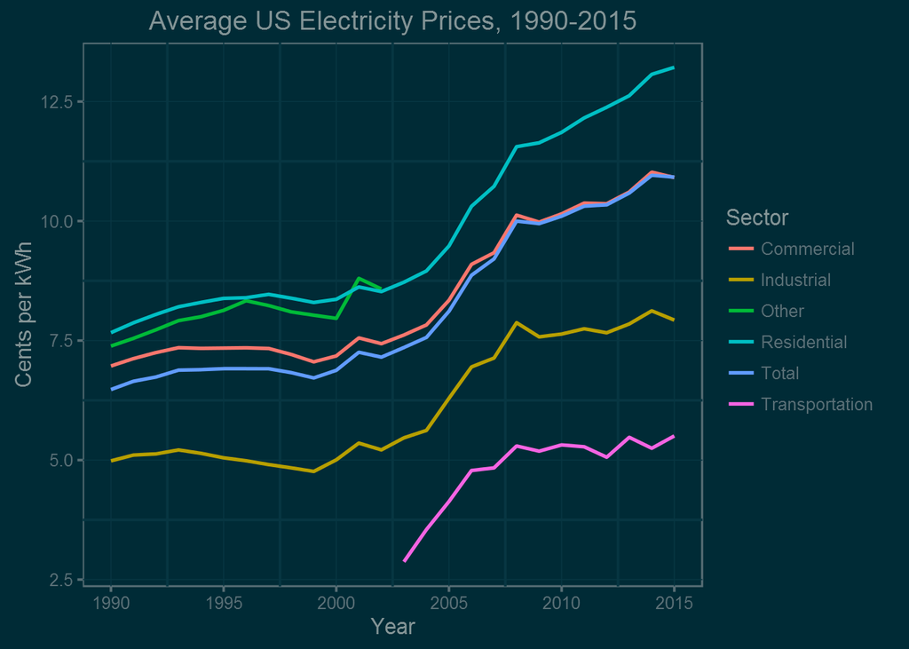

```r
ggplot(data[Industry=="Total Electric Industry", mean(Price), by=.(Year, Sector)],
       aes(x=Year, y=V1, col=Sector)) +
  geom_line(size=.7) +
  theme_solarized(light=F) +
  ggtitle("Average US Electricity Prices, 1990-2015") + ylab("Cents per kWh")
```

According to the data, the mean residential electricity price in 1990 was 7.66 cents/kWh, rising to 13.22 cents/kWh in 2015, a 72% increase. Commercial prices rose by 56% and industrial prices by 59%.

To get another sense of the data, I will make a state choropleth plot of the electricity prices. This involves pulling in a dataset from the `ggplot2` and `maps` packages that contains geospatial data for a US state map.

```r
data$id <- tolower(state.name[match(data$State,state.abb)])

us <- map_data("state")
us$stateid<-us$region
```

Now I will create a function that takes a year as an input and returns a choropleth using the average residential price for each state in that year:

```r
fun.stateplot <- function(year) {
  stateplot <- data %>%
    filter(State!="HI") %>%
    filter(State!="AK") %>%
    filter(Year==year) %>%
    filter(Industry=="Total Electric Industry") %>%
    filter(Sector=="Residential")

  ggplot() +
    geom_map(data=us, map=us,
                      aes(x=long, y=lat, map_id=stateid), fill="#ffffff", color="black", size=0.15) +
    geom_map(data=stateplot, map=us,
             aes(fill=Price, map_id=id), color="black", size=.15) +
    scale_fill_gradient2(low="red", mid="white", high="green", guide='colourbar', midpoint=(max(stateplot$Price)+min(stateplot$Price))/2) +
    #scale_fill_gradient2(low="red", mid="white", high="blue", guide='colourbar', midpoint=median(stateplot$Price)) +
    theme_map() +
    coord_map() +
    ggtitle(paste("US Residential Electricity Prices,",year))
}
```

Plots for 1990, 2002, and 2015:

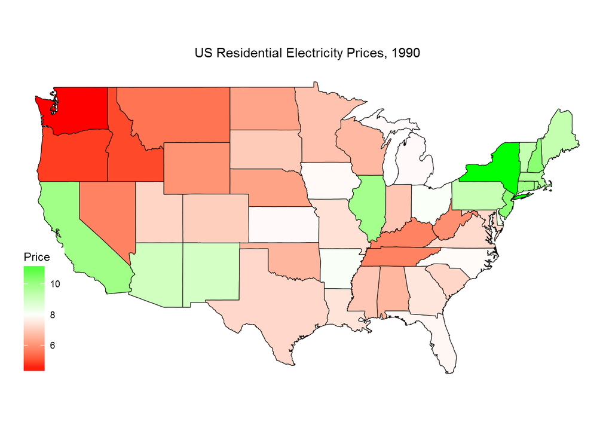

```r
fun.stateplot(1990)
```

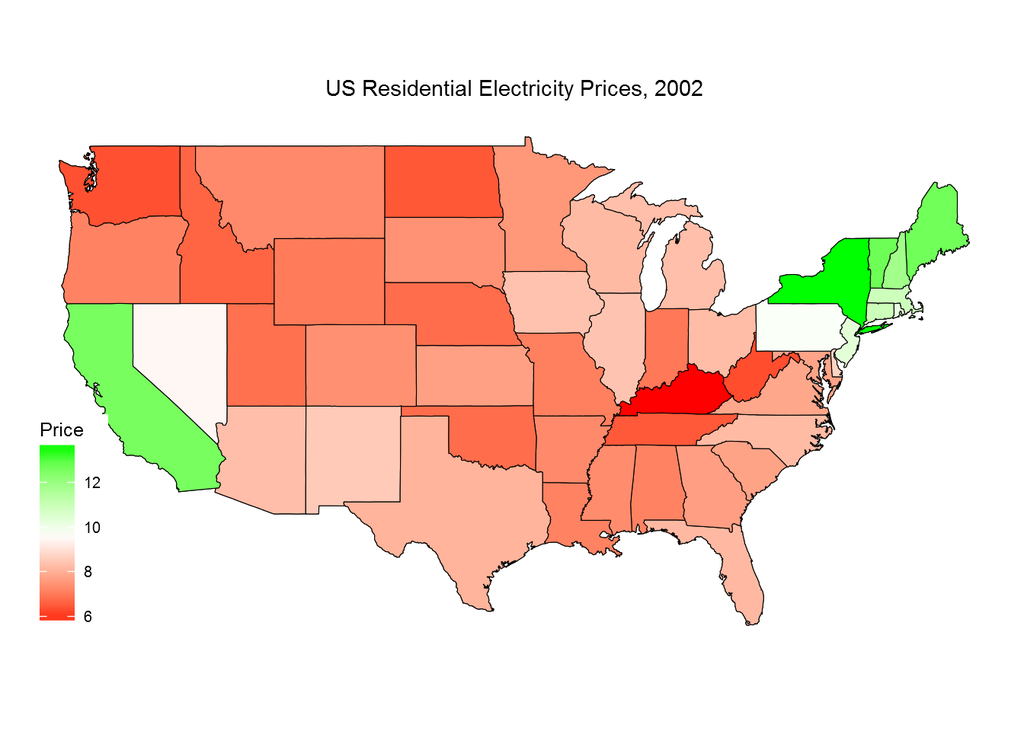

```r
fun.stateplot(2002)
```

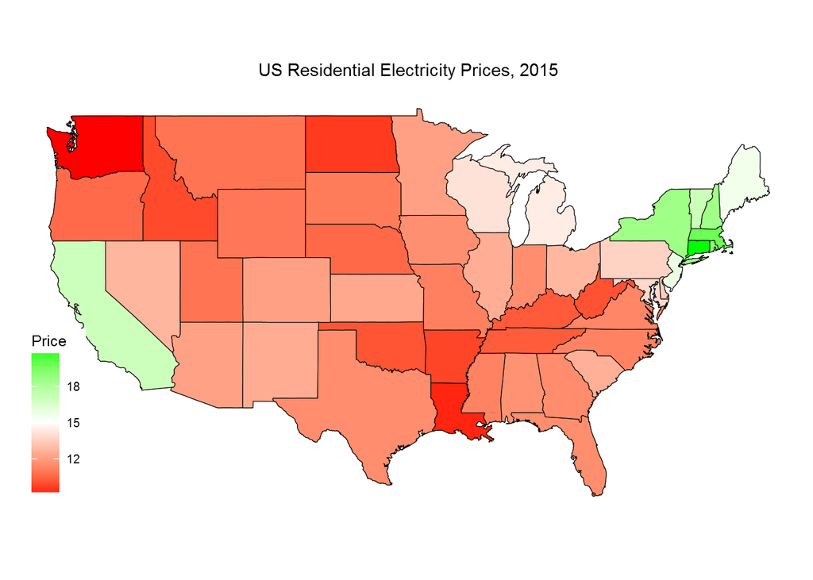

```r
fun.stateplot(2015)
```

Using a diverging color scale gives a good visual idea of the spread in prices between states. It is apparent looking at the maps for 1990 and 2015 that the price spread widened, as there are no states falling in the middle (the white range) in 2015 as there were in 1990. In 2015, the Northeastern states and California are the only states on the green side of the scale, while in 1990 there were many states in the middle and a more even distribution on either side of the middle range.

### Deregulation

Now, I will begin to look at deregulation’s effect on prices, first at a nationwide scale and then on a state-by-state basis.

The first states began deregulating electricity markets in the late 1990s. To start, I will evaluate energy prices for states that never deregulated and for those that did, not taking into account when they did so.

I determined which states had deregulated their electricity markets from this page from the EIA (http://www.eia.gov/electricity/policies/restructuring/restructure_elect.html) and created a new column in the data for whether they were deregulated as of 2015:

```r
dereg<- c("OR",
          "TX","MD","DC","DE",
          "IL","MI","OH",
          "NJ","NY","CT","RI","MA","NH","ME","PA")
data[, Deregulated := ifelse(State %in% dereg, T, F)] #create 'Dereg' column for deregulated states
rm(dereg)
setkey(data, Year)
```

A new dataset for the mean US prices by year, provider, sector and regulation status:

```r
totals <- data[Region!="US", .(MeanPrice=mean(Price)), by=.(Year, Industry, Sector, Deregulated)]
head(totals)
```

```
##    Year                Industry      Sector Deregulated MeanPrice
## 1: 1990 Total Electric Industry Residential       FALSE  7.176000
## 2: 1990 Total Electric Industry Residential        TRUE  8.725625
## 3: 1990  Full-Service Providers Residential       FALSE  7.176000
## 4: 1990  Full-Service Providers Residential        TRUE  8.725625
## 5: 1990 Total Electric Industry  Commercial       FALSE  6.545714
## 6: 1990 Total Electric Industry  Commercial        TRUE  7.868750
```

This graph shows the change in prices for states that deregulated at some point between 1990 and 2015 (dashed lines) and the others (solid lines):

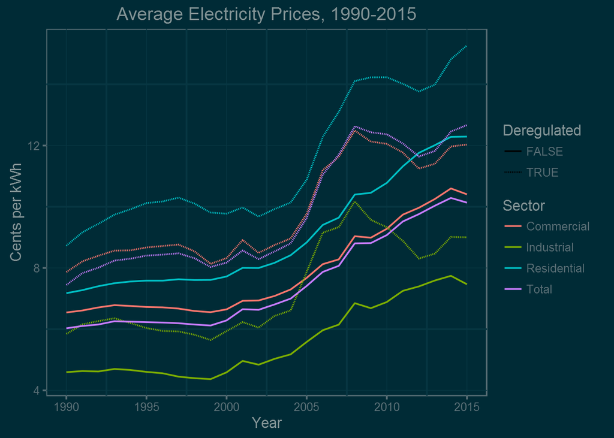

```r
ggplot(totals[Sector %in% c("Commercial","Industrial","Residential","Total") & Industry=="Total Electric Industry"],
       aes(x=Year, y=MeanPrice, col=Sector, linetype=Deregulated)) +
  geom_line() +
  ggtitle("Average Electricity Prices, 1990-2015") + ylab("Cents per kWh") +
  theme_solarized(light=F)
```

To look at the actual percent changes, I will calculate the percent difference between 1990 and 2015 prices in each sector, then create a bar chart:

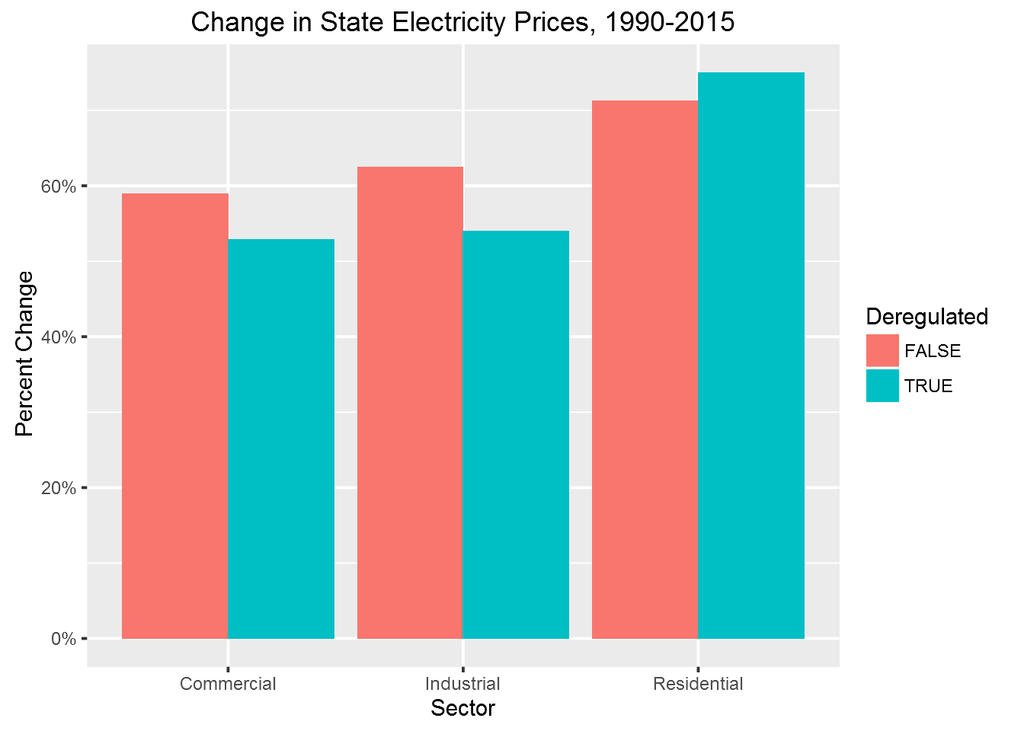

```r
ggplot(totals[Sector %in% c("Commercial","Industrial","Residential","Total") & Industry=="Total Electric Industry"][Year%in%c(1990,2015), .(`Percent Change`= (MeanPrice-shift(MeanPrice))/shift(MeanPrice)), by=.(Sector, Deregulated)][!is.na(`Percent Change`)][Sector!="Total"],
       aes(x=Sector, y=`Percent Change`, fill=Deregulated)) +
  geom_bar(stat='identity', position='dodge') +
  scale_y_continuous(labels=percent) +
  ggtitle("Change in State Electricity Prices, 1990-2015")
```

According to the data, residential prices in deregulated states rose faster than in regulated states, while commercial and industrial prices in deregulated states rose more slowly.

Next, I will look at the price difference between states that eventually deregulated and those that didn’t, from year to year. Doing this involves calculating the percent difference between deregulating states and other states for each year, also by sector. Then I will graph the data.

```r
totals2<-totals[Industry=="Total Electric Industry", .((MeanPrice-shift(MeanPrice))/shift(MeanPrice)), by=.(Year, Industry, Sector)]
totals2<-na.omit(totals2)
```

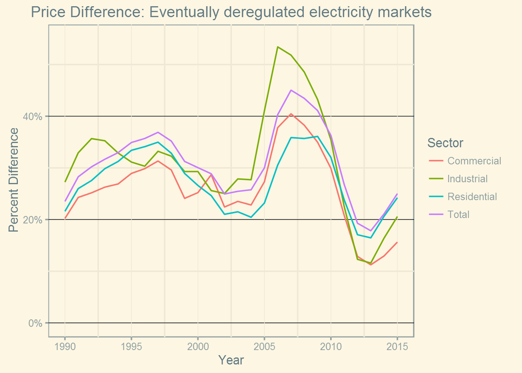

```r
ggplot(totals2[Sector%in% c("Commercial","Industrial","Residential","Total")], aes(x=Year, y=V1, col=Sector))+
  geom_line() +
  ggtitle("Price Difference: Eventually deregulated electricity markets") + ylab("Percent Difference") +
  theme_solarized() +
  theme(panel.grid.major.y = element_line(color = "black")) +
  scale_y_continuous(limits=c(0,.55), labels=percent)
```

Prices in deregulating states were always higher than in other states, starting at about 22% higher in 1990 on average. Over the course of the data, deregulating states’ electricity prices fluctuated greatly compared to other states’ prices, spiking to over 35% higher in 2006/2007 before dropping to their greatest parity in 2012/2013, nearing a 10% difference in some sectors.

#### Residential state-by-state deregulation

With the data available by state, I am able to make regional analyses of the prices, which I will do with Illinois and its neighbors.

Illinois deregulated its electricity market in 2002. I will make a new column, showing when a specific states market was regulated and not regulated. A `TRUE` value means it was deregulated that year.

```r
data[State=="IL", DR:= ifelse(Year>=2002, T, F),]
```

Looking at the Illinois data with a change in line type at the time of deregulation:

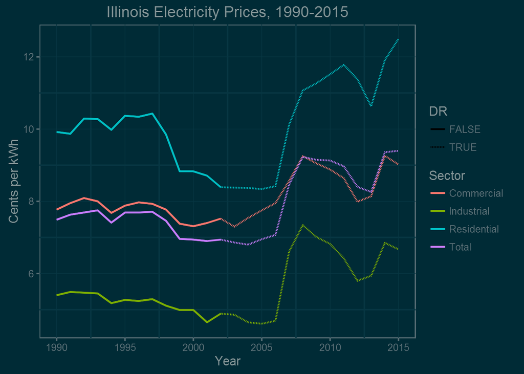

```r
IL<-data[State=="IL" & Industry=="Total Electric Industry" & Sector != "Transportation" & Sector != "Other"]
ggplot(IL[Year<=2002], aes(x=Year, y=Price, col=Sector))+
  geom_line(size=.6) +
  geom_line(data=IL, aes(x=Year, y=Price, col=Sector, linetype=DR), size=.6) +
  theme_solarized(light=F) +
  ggtitle("Illinois Electricity Prices, 1990-2015") + ylab("Cents per kWh")
```

Though already somewhat volatile in residential prices, following deregulation Illinois’ electricity prices appear to have become very sensitive to market factors, showing steep price increases and significant decreases not evident before the switch.

Illinois is an interesting case as it is the only state of it and its five neighbors to deregulate its electricity market. Although many factors go into electricity pricing independent of geographic proximity and deregulation, such as population density, demand and existing production sources, it will be interesting to compare residential price changes in all six states.

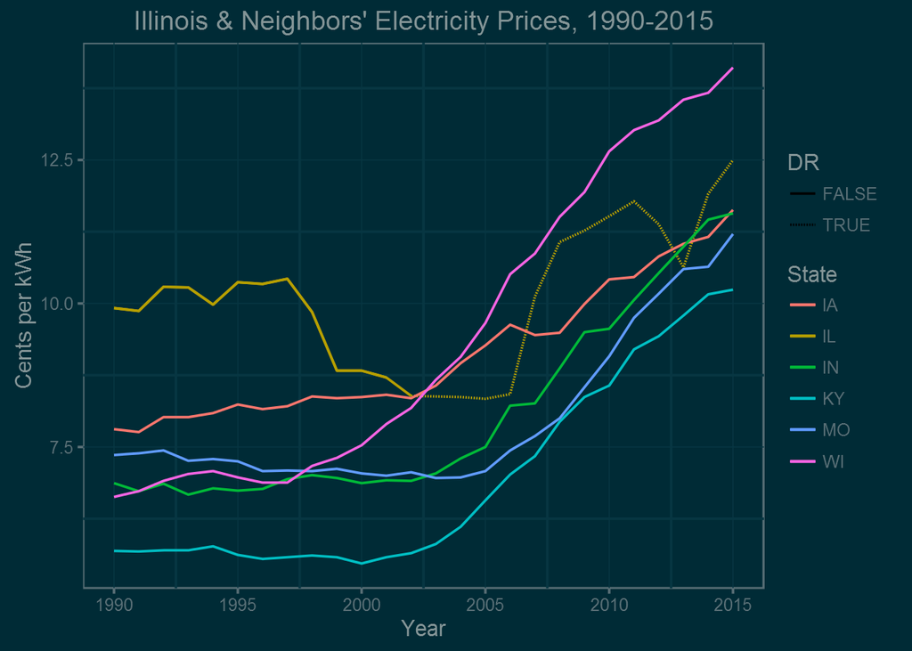

```r
mWest <- data[State %in% c("IA","WI","IN","MO","KY") & Sector=="Residential" & Industry=="Total Electric Industry"]
IL2 <- data[State=="IL" & Industry=="Total Electric Industry" & Sector=="Residential"]
ggplot(IL2[Year<=2002], aes(x=Year, y=Price, col=State)) +
  geom_line() +
  geom_line(data=IL2, aes(x=Year, y=Price, linetype=DR)) +
  geom_line(data=mWest, aes(x=Year, y=Price, col=State)) +
  theme_solarized(light=F) +
  ggtitle("Illinois & Neighbors' Electricity Prices, 1990-2015") + ylab("Cents per kWh")
```

The volatile price fluctuations of the deregulated electricity markets must be compared to the slow but steady upward march of the regulated markets, most of which are utility monopolies. Though not conclusive as to the benefit to consumers, this data has shown in clear terms the influence that adding competition to a market will have on prices.